# Project_6_Material_mfg

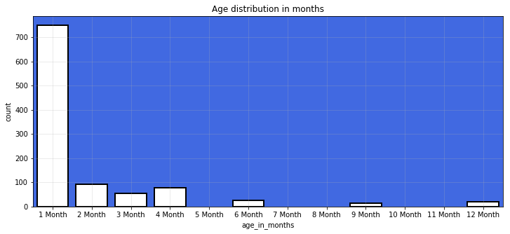

```python
plt.figure(figsize=(12,5))

month_sort = ['1 Month','2 Month','3 Month','4 Month','5 Month','6 Month','7 Month','8 Month','9 Month','10 Month','11 Month','12 Month']

axes = sns.countplot(conDF['age_in_months'],order=month_sort,linewidth=2,edgecolor="k"*len(month_sort),palette=["w"])
axes.set_facecolor("royalblue")
plt.title("Age distribution in months")
plt.grid(True,alpha=.3)
plt.show()
```

```python
del conDF['age_in_months']
conDF.head()
```

|  | cement | slag | ash | water | superplastic | coarseagg | fineagg | age | strength |
| --- | --- | --- | --- | --- | --- | --- | --- | --- | --- |
| 0 | 141.3 | 212.0 | 0.0 | 203.5 | 0.0 | 971.8 | 748.5 | 28 | 29.89 |
| 1 | 168.9 | 42.2 | 124.3 | 158.3 | 10.8 | 1080.8 | 796.2 | 14 | 23.51 |
| 2 | 250.0 | 0.0 | 95.7 | 187.4 | 5.5 | 956.9 | 861.2 | 28 | 29.22 |
| 3 | 266.0 | 114.0 | 0.0 | 228.0 | 0.0 | 932.0 | 670.0 | 28 | 45.85 |
| 4 | 154.8 | 183.4 | 0.0 | 193.3 | 9.1 | 1047.4 | 696.7 | 28 | 18.29 |

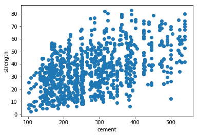

```python
plt.scatter(conDF['cement'], conDF['strength'])
plt.xlabel('cement')
plt.ylabel('strength')
```

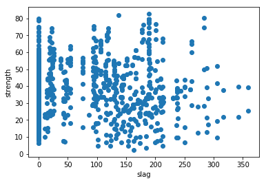

```python
plt.scatter(conDF['slag'], conDF['strength'])
plt.xlabel('slag')
plt.ylabel('strength')
```

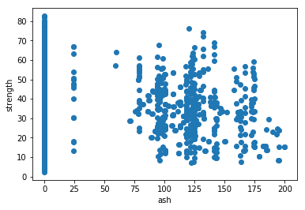

```python
plt.scatter(conDF['ash'], conDF['strength'])
plt.xlabel('ash')
plt.ylabel('strength')
```

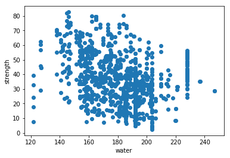

```python
plt.scatter(conDF['water'], conDF['strength'])
plt.xlabel('water')
plt.ylabel('strength')
```

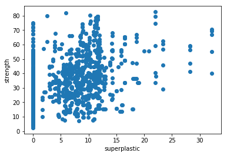

```python
plt.scatter(conDF['superplastic'], conDF['strength'])
plt.xlabel('superplastic')
plt.ylabel('strength')
```

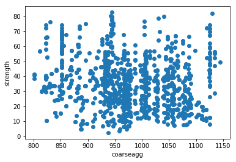

```python
plt.scatter(conDF['coarseagg'], conDF['strength'])
plt.xlabel('coarseagg')
plt.ylabel('strength')
```

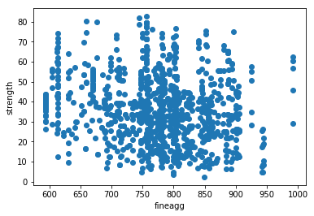

```python
plt.scatter(conDF['fineagg'], conDF['strength'])
plt.xlabel('fineagg')
plt.ylabel('strength')
```

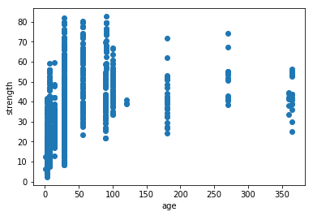

```python
plt.scatter(conDF['age'], conDF['strength'])
plt.xlabel('age')
plt.ylabel('strength')
```

Seeing the percentage of outlier in the dataset

```python
age_outlier_cnt = conDF[conDF['age']>150].shape
age_outlier_cnt
```

```
(59, 9)
```

```python
# Percentage calculation
outlier_percent = (age_outlier_cnt[0]/Shape[0])*100
outlier_percent
```

```
5.728155339805825
```

```python
concrete = conDF[conDF['age']<150]
```

```python
#2. Deliverable -2  (Feature Engineering techniques)
#a. Identify opportunities (if any) to create a composite feature, drop a feature
#b. Decide on complexity of the model, should it be simple linear mode in terms of parameters or would a quadratic or
#   higher degree help
#c. Explore for gaussians. If data is likely to be a mix of gaussians, explore individual clusters and present your
#   findings in terms of the independent attributes and their suitability to predict strength
```

```python
from sklearn.decomposition import PCA
from sklearn.pipeline import Pipeline
```

```python
# Lets check for highly correlated variables from the original dataset
cor= conDF.corr()
cor.loc[:,:] = np.tril(cor,k=-1)
cor=cor.stack()
cor[(cor > 0.55) | (cor< -0.55)]
```

```
superplastic  water   -0.657533
dtype: float64
```

```python
# Lets check for highly correlated variables from the age outliers removed dataset
cor_concrete= concrete.corr()
cor_concrete.loc[:,:] = np.tril(cor_concrete,k=-1)
cor_concrete=cor_concrete.stack()
cor_concrete[(cor_concrete > 0.55) | (cor_concrete < -0.55)]
```

```
superplastic  water   -0.642786
dtype: float64
```

There is no much difference in correlation even after removing the age oulier. We have planned to use original dataset.

```python
X = conDF.iloc[:,:-1]
y = conDF.iloc[:,-1:]
```

```python
print ("X shape : ", X.shape)
print ("y shape : ", y.shape)
```

```
X shape :  (1030, 8)
y shape :  (1030, 1)
```

```python
size=0.3
random=7
X_train, X_test, y_train, y_test = train_test_split(X, y, test_size=size, random_state=random)
#X_train, X_val, y_train, y_val = train_test_split(X_train, y_train, test_size=size, random_state=random)
```

```python
print ("X_train Shape : ", X_train.shape)
print ("y_train Shape : ", y_train.shape)
print ("X_test Shape : ", X_test.shape)
print ("y_test Shape : ", y_test.shape)
```

```
X_train Shape :  (721, 8)
y_train Shape :  (721, 1)
X_test Shape :  (309, 8)
y_test Shape :  (309, 1)
```

```python
# Scaling the dataset before model building
scaler = StandardScaler()

X_train_norm = scaler.fit_transform(X_train)
X_test_norm  = scaler.fit_transform(X_test)
```

```python
def regression_scores(ypredict):
    mse = mean_squared_error(y_test, ypredict)
    mae = mean_absolute_error(y_true=y_test, y_pred=ypredict)
    rmse = np.sqrt(mean_squared_error(y_test, ypredict))
    r2 = r2_score(y_test, ypredict)

    return mse, mae, rmse, r2
```

```python
result_df = pd.DataFrame()
def result(method, scr, mse, mae, rmse, r2):
    global result_df
    temp_result = pd.DataFrame({'Method':method,
                            'Score':scr,
                            'MSE':mse,
                            'MAE':mae,
                            'RMSE':rmse,
                            'R Squared':r2},index=[0])
    result_df = pd.concat([result_df, temp_result])
```

### Linear Regression

```python
lr = LinearRegression()
lr.fit(X_train_norm, y_train)
y_predict = lr.predict(X_test_norm)
score = lr.score(X_test_norm, y_test)
mse, mae, rmse, r_sqrd = regression_scores(y_predict)
```

```python
#pipe_lr = Pipeline([('scl',StandardScaler()),('pca',PCA()),('lr',LinearRegression())])
```

```python
result('Linear Regression', score, mse, mae, rmse, r_sqrd)
result_df
```

|  | Method | Score | MSE | MAE | RMSE | R Squared |
| --- | --- | --- | --- | --- | --- | --- |
| 0 | Linear Regression | 0.622087 | 97.721037 | 7.812406 | 9.885395 | 0.622087 |

### Support Vector Regressor

```python
svr = SVR()
svr.fit(X_train_norm, y_train)
y_predict = svr.predict(X_test_norm)
score = svr.score(X_test_norm, y_test)
mse, mae, rmse, r_sqrd = regression_scores(y_predict)
```

```python
result('Support Vector Regressor', score, mse, mae, rmse, r_sqrd)
result_df
```

|  | Method | Score | MSE | MAE | RMSE | R Squared |
| --- | --- | --- | --- | --- | --- | --- |
| 0 | Linear Regression | 0.622087 | 97.721037 | 7.812406 | 9.885395 | 0.622087 |
| 0 | Support Vector Regressor | 0.655883 | 88.982024 | 7.519929 | 9.433028 | 0.655883 |

### Decision Tree Regressor

```python
dtr = DecisionTreeRegressor()
dtr.fit(X_train_norm, y_train)
y_predict = dtr.predict(X_test_norm)
score = dtr.score(X_test_norm, y_test)
mse, mae, rmse, r_sqrd = regression_scores(y_predict)
```

```python
result('Decision Tree Regressor', score, mse, mae, rmse, r_sqrd)
result_df
```

|  | Method | Score | MSE | MAE | RMSE | R Squared |
| --- | --- | --- | --- | --- | --- | --- |
| 0 | Linear Regression | 0.622087 | 97.721037 | 7.812406 | 9.885395 | 0.622087 |
| 0 | Support Vector Regressor | 0.655883 | 88.982024 | 7.519929 | 9.433028 | 0.655883 |
| 0 | Decision Tree Regressor | 0.739815 | 67.278863 | 5.684126 | 8.202369 | 0.739815 |

### Random Forest Regressor

```python
rfr = RandomForestRegressor()
rfr.fit(X_train_norm, y_train)
y_predict = rfr.predict(X_test_norm)
score = rfr.score(X_test_norm, y_test)
mse, mae, rmse, r_sqrd = regression_scores(y_predict)
```

```python
result('Random Forest Regressor', score, mse, mae, rmse, r_sqrd)
result_df
```

|  | Method | Score | MSE | MAE | RMSE | R Squared |
| --- | --- | --- | --- | --- | --- | --- |
| 0 | Linear Regression | 0.622087 | 97.721037 | 7.812406 | 9.885395 | 0.622087 |
| 0 | Support Vector Regressor | 0.655883 | 88.982024 | 7.519929 | 9.433028 | 0.655883 |
| 0 | Decision Tree Regressor | 0.739815 | 67.278863 | 5.684126 | 8.202369 | 0.739815 |
| 0 | Random Forest Regressor | 0.828811 | 44.266133 | 5.089427 | 6.653280 | 0.828811 |

### Gradient Boosting Regressor

```python
gbr = GradientBoostingRegressor()
gbr.fit(X_train_norm, y_train)
y_predict = gbr.predict(X_test_norm)
score = gbr.score(X_test_norm, y_test)
mse, mae, rmse, r_sqrd = regression_scores(y_predict)
```

```python
result('Gradient Boosting Regressor', score, mse, mae, rmse, r_sqrd)
result_df
```

|  | Method | Score | MSE | MAE | RMSE | R Squared |
| --- | --- | --- | --- | --- | --- | --- |
| 0 | Linear Regression | 0.622087 | 97.721037 | 7.812406 | 9.885395 | 0.622087 |
| 0 | Support Vector Regressor | 0.655883 | 88.982024 | 7.519929 | 9.433028 | 0.655883 |
| 0 | Decision Tree Regressor | 0.739815 | 67.278863 | 5.684126 | 8.202369 | 0.739815 |
| 0 | Random Forest Regressor | 0.828811 | 44.266133 | 5.089427 | 6.653280 | 0.828811 |
| 0 | Gradient Boosting Regressor | 0.833019 | 43.178135 | 5.144317 | 6.571007 | 0.833019 |

### Ada Boost Regressor

```python
abr = AdaBoostRegressor()
abr.fit(X_train_norm, y_train)
y_predict = abr.predict(X_test_norm)
score = abr.score(X_test_norm, y_test)
mse, mae, rmse, r_sqrd = regression_scores(y_predict)
```

```python
result('Ada Boost Regressor', score, mse, mae, rmse, r_sqrd)
result_df
```

|  | Method | Score | MSE | MAE | RMSE | R Squared |
| --- | --- | --- | --- | --- | --- | --- |
| 0 | Linear Regression | 0.622087 | 97.721037 | 7.812406 | 9.885395 | 0.622087 |
| 0 | Support Vector Regressor | 0.655883 | 88.982024 | 7.519929 | 9.433028 | 0.655883 |
| 0 | Decision Tree Regressor | 0.739815 | 67.278863 | 5.684126 | 8.202369 | 0.739815 |
| 0 | Random Forest Regressor | 0.828811 | 44.266133 | 5.089427 | 6.653280 | 0.828811 |
| 0 | Gradient Boosting Regressor | 0.833019 | 43.178135 | 5.144317 | 6.571007 | 0.833019 |
| 0 | Ada Boost Regressor | 0.722753 | 71.690841 | 6.978157 | 8.467044 | 0.722753 |

```python
# 3. Deliverable -3  (create the model )
# a. Obtain feature importance for the individual features using multiple methods and present your findings
```

### Extracting feature importance from the best scored models

### Decision Tree Regressor

```python
conDF.columns
```

```
Index(['cement', 'slag', 'ash', 'water', 'superplastic', 'coarseagg',
       'fineagg', 'age', 'strength'],
      dtype='object')
```

```python
## Removing age feature from independent variables

if X_train_norm.shape[1] > 7:
    X_train_wo_age = np.delete(X_train_norm, 7, 1)
if X_test_norm.shape[1] > 7:
    X_test_wo_age = np.delete(X_test_norm, 7, 1)

print ("X_train_norm Shape : ", X_train_norm.shape)
print ("X_train_wo_age Shape : ", X_train_wo_age.shape)
print ("y_train Shape : ", y_train.shape)
print ("X_test_norm Shape : ", X_test_norm.shape)
print ("X_test_wo_age Shape : ", X_test_wo_age.shape)
print ("y_test Shape : ", y_test.shape)
```

```
X_train_norm Shape :  (721, 8)
X_train_wo_age Shape :  (721, 7)
y_train Shape :  (721, 1)
X_test_norm Shape :  (309, 8)
X_test_wo_age Shape :  (309, 7)
y_test Shape :  (309, 1)
```

```python
dt = DecisionTreeRegressor()
dt.get_params()
```

```
{'criterion': 'mse',
 'max_depth': None,
 'max_features': None,
 'max_leaf_nodes': None,
 'min_impurity_decrease': 0.0,
 'min_impurity_split': None,
 'min_samples_leaf': 1,
 'min_samples_split': 2,
 'min_weight_fraction_leaf': 0.0,
 'presort': False,
 'random_state': None,
 'splitter': 'best'}
```

```python
dt_params = {
    "max_depth" : [None,1,2,3,4,5],
    "min_samples_leaf" : range(1,3),
    "min_samples_split" : range(2,10),
    "max_leaf_nodes" : range(10,18)
}
```

```python
dt_grid = GridSearchCV(estimator=dt,
                      param_grid = dt_params,
                      cv = 7)
dt_grid_wo_age = GridSearchCV(estimator=dt,
                      param_grid = dt_params,
                      cv = 7)
```

```python
dt_grid.fit(X_train_norm, y_train)
```

```
GridSearchCV(cv=7, error_score='raise-deprecating',
       estimator=DecisionTreeRegressor(criterion='mse', max_depth=None, max_features=None,
           max_leaf_nodes=None, min_impurity_decrease=0.0,
           min_impurity_split=None, min_samples_leaf=1,
           min_samples_split=2, min_weight_fraction_leaf=0.0,
           presort=False, random_state=None, splitter='best'),
       fit_params=None, iid='warn', n_jobs=None,
       param_grid={'max_depth': [None, 1, 2, 3, 4, 5], 'min_samples_leaf': range(1, 3), 'min_samples_split': range(2, 10), 'max_leaf_nodes': range(10, 18)},
       pre_dispatch='2*n_jobs', refit=True, return_train_score='warn',
       scoring=None, verbose=0)
```

```python
best_hyperparams = dt_grid.best_params_
dt_model = dt_grid.best_estimator_

y_predict = dt_model.predict(X_test_norm)
score = dt_model.score(X_test_norm, y_test)
mse, mae, rmse, r_sqrd = regression_scores(y_predict)
result('Decision Tree Featurization', score, mse, mae, rmse, r_sqrd)
result_df
```

|  | Method | Score | MSE | MAE | RMSE | R Squared |
| --- | --- | --- | --- | --- | --- | --- |
| 0 | Linear Regression | 0.622087 | 97.721037 | 7.812406 | 9.885395 | 0.622087 |
| 0 | Support Vector Regressor | 0.655883 | 88.982024 | 7.519929 | 9.433028 | 0.655883 |
| 0 | Decision Tree Regressor | 0.739815 | 67.278863 | 5.684126 | 8.202369 | 0.739815 |
| 0 | Random Forest Regressor | 0.828811 | 44.266133 | 5.089427 | 6.653280 | 0.828811 |
| 0 | Gradient Boosting Regressor | 0.833019 | 43.178135 | 5.144317 | 6.571007 | 0.833019 |
| 0 | Ada Boost Regressor | 0.722753 | 71.690841 | 6.978157 | 8.467044 | 0.722753 |
| 0 | Decision Tree Featurization | 0.629053 | 95.919878 | 7.639499 | 9.793869 | 0.629053 |

```python
best_hyperparams
```

```
{'max_depth': 5,
 'max_leaf_nodes': 17,
 'min_samples_leaf': 1,
 'min_samples_split': 2}
```

```python
dt_model
```

```
DecisionTreeRegressor(criterion='mse', max_depth=5, max_features=None,
           max_leaf_nodes=17, min_impurity_decrease=0.0,
           min_impurity_split=None, min_samples_leaf=1,
           min_samples_split=2, min_weight_fraction_leaf=0.0,
           presort=False, random_state=None, splitter='best')
```

```python
dt_grid_wo_age.fit(X_train_wo_age, y_train)
best_hp_wo_age = dt_grid_wo_age.best_params_
dt_model_wo_age = dt_grid_wo_age.best_estimator_

y_predict = dt_model_wo_age.predict(X_test_wo_age)
score = dt_model_wo_age.score(X_test_wo_age, y_test)
mse, mae, rmse, r_sqrd = regression_scores(y_predict)
result('Decision Tree Without Age', score, mse, mae, rmse, r_sqrd)
result_df
```

|  | Method | Score | MSE | MAE | RMSE | R Squared |
| --- | --- | --- | --- | --- | --- | --- |
| 0 | Linear Regression | 0.622087 | 97.721037 | 7.812406 | 9.885395 | 0.622087 |
| 0 | Support Vector Regressor | 0.655883 | 88.982024 | 7.519929 | 9.433028 | 0.655883 |
| 0 | Decision Tree Regressor | 0.739815 | 67.278863 | 5.684126 | 8.202369 | 0.739815 |
| 0 | Random Forest Regressor | 0.828811 | 44.266133 | 5.089427 | 6.653280 | 0.828811 |
| 0 | Gradient Boosting Regressor | 0.833019 | 43.178135 | 5.144317 | 6.571007 | 0.833019 |
| 0 | Ada Boost Regressor | 0.722753 | 71.690841 | 6.978157 | 8.467044 | 0.722753 |
| 0 | Decision Tree Featurization | 0.629053 | 95.919878 | 7.639499 | 9.793869 | 0.629053 |
| 0 | Decision Tree Without Age | 0.311823 | 177.949305 | 10.584243 | 13.339764 | 0.311823 |

```python
best_hp_wo_age
```

```
{'max_depth': 5,
 'max_leaf_nodes': 17,
 'min_samples_leaf': 2,
 'min_samples_split': 4}
```

```python
dt_model_wo_age
```

```
DecisionTreeRegressor(criterion='mse', max_depth=5, max_features=None,
           max_leaf_nodes=17, min_impurity_decrease=0.0,
           min_impurity_split=None, min_samples_leaf=2,
           min_samples_split=4, min_weight_fraction_leaf=0.0,
           presort=False, random_state=None, splitter='best')
```

### Random Forest

```python
rf = RandomForestRegressor()
rf.get_params()
```

```
{'bootstrap': True,
 'criterion': 'mse',
 'max_depth': None,
 'max_features': 'auto',
 'max_leaf_nodes': None,
 'min_impurity_decrease': 0.0,
 'min_impurity_split': None,
 'min_samples_leaf': 1,
 'min_samples_split': 2,
 'min_weight_fraction_leaf': 0.0,
 'n_estimators': 'warn',
 'n_jobs': None,
 'oob_score': False,
 'random_state': None,
 'verbose': 0,
 'warm_start': False}
```

```python
rf_params = {'n_estimators':[70,75,80,85],
            'max_depth':[9,10,11],
            'min_samples_leaf':range(2,5),
            'max_features':['auto','log2']}
```

```python
rf_grid = GridSearchCV(estimator=rf,
                       param_grid=rf_params,
                       cv=5,
                       scoring='neg_mean_squared_error',
                       n_jobs=-1,
                       verbose=1)
rf_grid_wo_age = GridSearchCV(estimator=rf,
                       param_grid=rf_params,
                       cv=5,
                       scoring='neg_mean_squared_error',
                       n_jobs=-1,
                       verbose=1)
```

```python
# Data array with Age feature
rf_grid.fit(X_train_norm, y_train)

# Age feature removed data array
rf_grid_wo_age.fit(X_train_wo_age, y_train)
```

```
Fitting 5 folds for each of 72 candidates, totalling 360 fits
```

```
[Parallel(n_jobs=-1)]: Using backend LokyBackend with 4 concurrent workers.
[Parallel(n_jobs=-1)]: Done  42 tasks      | elapsed:   21.9s
[Parallel(n_jobs=-1)]: Done 192 tasks      | elapsed:   52.6s
[Parallel(n_jobs=-1)]: Done 360 out of 360 | elapsed:  1.4min finished
```

```
Fitting 5 folds for each of 72 candidates, totalling 360 fits
```

```
[Parallel(n_jobs=-1)]: Using backend LokyBackend with 4 concurrent workers.
[Parallel(n_jobs=-1)]: Done  42 tasks      | elapsed:   10.7s
[Parallel(n_jobs=-1)]: Done 192 tasks      | elapsed:   39.1s
[Parallel(n_jobs=-1)]: Done 360 out of 360 | elapsed:  1.2min finished
```

```
GridSearchCV(cv=5, error_score='raise-deprecating',
       estimator=RandomForestRegressor(bootstrap=True, criterion='mse', max_depth=None,
           max_features='auto', max_leaf_nodes=None,
           min_impurity_decrease=0.0, min_impurity_split=None,
           min_samples_leaf=1, min_samples_split=2,
           min_weight_fraction_leaf=0.0, n_estimators='warn', n_jobs=None,
           oob_score=False, random_state=None, verbose=0, warm_start=False),
       fit_params=None, iid='warn', n_jobs=-1,
       param_grid={'n_estimators': [70, 75, 80, 85], 'max_depth': [9, 10, 11], 'min_samples_leaf': range(2, 5), 'max_features': ['auto', 'log2']},
       pre_dispatch='2*n_jobs', refit=True, return_train_score='warn',
       scoring='neg_mean_squared_error', verbose=1)
```

```python
best_hyperparams = rf_grid.best_params_
rf_model = rf_grid.best_estimator_

y_predict = rf_model.predict(X_test_norm)
#rmse = np.sqrt(y_test, y_predict)
score = rf_model.score(X_test_norm, y_test)
mse, mae, rmse, r_sqrd = regression_scores(y_predict)
result('Random Forest Featurization', score, mse, mae, rmse, r_sqrd)
result_df
```

|  | Method | Score | MSE | MAE | RMSE | R Squared |
| --- | --- | --- | --- | --- | --- | --- |
| 0 | Linear Regression | 0.622087 | 97.721037 | 7.812406 | 9.885395 | 0.622087 |
| 0 | Support Vector Regressor | 0.655883 | 88.982024 | 7.519929 | 9.433028 | 0.655883 |
| 0 | Decision Tree Regressor | 0.739815 | 67.278863 | 5.684126 | 8.202369 | 0.739815 |
| 0 | Random Forest Regressor | 0.828811 | 44.266133 | 5.089427 | 6.653280 | 0.828811 |
| 0 | Gradient Boosting Regressor | 0.833019 | 43.178135 | 5.144317 | 6.571007 | 0.833019 |
| 0 | Ada Boost Regressor | 0.722753 | 71.690841 | 6.978157 | 8.467044 | 0.722753 |
| 0 | Decision Tree Featurization | 0.629053 | 95.919878 | 7.639499 | 9.793869 | 0.629053 |
| 0 | Decision Tree Without Age | 0.311823 | 177.949305 | 10.584243 | 13.339764 | 0.311823 |
| 0 | Random Forest Featurization | 0.853910 | 37.775974 | 4.892567 | 6.146216 | 0.853910 |

```python
## Random Forest model without Age feature
best_hp_wo_age = rf_grid_wo_age.best_params_
rf_model_wo_age = rf_grid_wo_age.best_estimator_

y_predict = rf_model_wo_age.predict(X_test_wo_age)
#rmse = np.sqrt(y_test, y_predict)
score = rf_model_wo_age.score(X_test_wo_age, y_test)
mse, mae, rmse, r_sqrd = regression_scores(y_predict)
result('Random Forest Without Age', score, mse, mae, rmse, r_sqrd)
result_df
```

|  | Method | Score | MSE | MAE | RMSE | R Squared |
| --- | --- | --- | --- | --- | --- | --- |
| 0 | Linear Regression | 0.622087 | 97.721037 | 7.812406 | 9.885395 | 0.622087 |
| 0 | Support Vector Regressor | 0.655883 | 88.982024 | 7.519929 | 9.433028 | 0.655883 |
| 0 | Decision Tree Regressor | 0.739815 | 67.278863 | 5.684126 | 8.202369 | 0.739815 |
| 0 | Random Forest Regressor | 0.828811 | 44.266133 | 5.089427 | 6.653280 | 0.828811 |
| 0 | Gradient Boosting Regressor | 0.833019 | 43.178135 | 5.144317 | 6.571007 | 0.833019 |
| 0 | Ada Boost Regressor | 0.722753 | 71.690841 | 6.978157 | 8.467044 | 0.722753 |
| 0 | Decision Tree Featurization | 0.629053 | 95.919878 | 7.639499 | 9.793869 | 0.629053 |
| 0 | Decision Tree Without Age | 0.311823 | 177.949305 | 10.584243 | 13.339764 | 0.311823 |
| 0 | Random Forest Featurization | 0.853910 | 37.775974 | 4.892567 | 6.146216 | 0.853910 |
| 0 | Random Forest Without Age | 0.498385 | 129.708161 | 9.250413 | 11.388949 | 0.498385 |

```python
best_hyperparams
```

```
{'max_depth': 10,
 'max_features': 'auto',
 'min_samples_leaf': 2,
 'n_estimators': 85}
```

```python
# Without Age feature
best_hp_wo_age
```

```
{'max_depth': 9,
 'max_features': 'log2',
 'min_samples_leaf': 4,
 'n_estimators': 85}
```

```python
rf_model
```

```
RandomForestRegressor(bootstrap=True, criterion='mse', max_depth=10,
           max_features='auto', max_leaf_nodes=None,
           min_impurity_decrease=0.0, min_impurity_split=None,
           min_samples_leaf=2, min_samples_split=2,
           min_weight_fraction_leaf=0.0, n_estimators=85, n_jobs=None,
           oob_score=False, random_state=None, verbose=0, warm_start=False)
```

```python
# Without Age feature
rf_model_wo_age
```

```
RandomForestRegressor(bootstrap=True, criterion='mse', max_depth=9,
           max_features='log2', max_leaf_nodes=None,
           min_impurity_decrease=0.0, min_impurity_split=None,
           min_samples_leaf=4, min_samples_split=2,
           min_weight_fraction_leaf=0.0, n_estimators=85, n_jobs=None,
           oob_score=False, random_state=None, verbose=0, warm_start=False)
```

```python
rf_model.estimators_
```

[output not shown]

[output cut: 370 more lines]

[output not shown]

```python
# Without Age feature
rf_model_wo_age.estimators_
```

[output not shown]

[output cut: 370 more lines]

[output not shown]

```python
rf_model.n_estimators
```

```
85
```

```python
# Without Age feature
rf_model_wo_age.n_estimators
```

```
85
```

```python
# Get the numerical feature importance
rf_importance = list(rf_model.feature_importances_)
feature_list = list(conDF.columns)[:-1]

print ("rf_importance : ", rf_importance)
print ("feature_list : ", feature_list)

feature_importance = [(feature, round(importance,3)) for feature, importance in zip(feature_list, rf_importance)]
sorted_importance = sorted(feature_importance, key = lambda x : x[1],reverse=True)

# Print out the feature and importances
[print('Variable: {:20} Importance: {}'.format(*pair)) for pair in feature_importance]
```

```
rf_importance :  [0.2925094628238641, 0.06978135672761392, 0.019193354801584687, 0.12223437949873463, 0.08734425333151438, 0.02317343477068901, 0.03576405616792744, 0.34999970187807183]
feature_list :  ['cement', 'slag', 'ash', 'water', 'superplastic', 'coarseagg', 'fineagg', 'age']
Variable: cement               Importance: 0.293
Variable: slag                 Importance: 0.07
Variable: ash                  Importance: 0.019
Variable: water                Importance: 0.122
Variable: superplastic         Importance: 0.087
Variable: coarseagg            Importance: 0.023
Variable: fineagg              Importance: 0.036
Variable: age                  Importance: 0.35
```

```
[None, None, None, None, None, None, None, None]
```

```python
## WITHOUT AGE FEATURE
# Get the numerical feature importance
rf_imp_wo_age = list(rf_model_wo_age.feature_importances_)
feature_list_wo_age = list(conDF.columns)[:-2]

print ("rf_importance : ", rf_imp_wo_age)
print ("feature_list : ", feature_list_wo_age)

feature_imp_wo_age = [(feature, round(importance,3)) for feature, importance in zip(feature_list_wo_age, rf_imp_wo_age)]
sorted_imp_wo_age = sorted(feature_imp_wo_age, key = lambda x : x[1],reverse=True)

# Print out the feature and importances
[print('Variable: {:20} Importance: {}'.format(*pair)) for pair in feature_imp_wo_age]
```

```
rf_importance :  [0.3372115154801542, 0.08415900098411046, 0.0643333613965218, 0.19769271005751926, 0.11482099115510301, 0.10481420703732508, 0.09696821388926617]
feature_list :  ['cement', 'slag', 'ash', 'water', 'superplastic', 'coarseagg', 'fineagg']
Variable: cement               Importance: 0.337
Variable: slag                 Importance: 0.084
Variable: ash                  Importance: 0.064
Variable: water                Importance: 0.198
Variable: superplastic         Importance: 0.115
Variable: coarseagg            Importance: 0.105
Variable: fineagg              Importance: 0.097
```

```
[None, None, None, None, None, None, None]
```

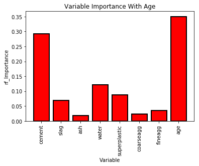

```python
# List of x locations for plotting
x_values = list(range(len(rf_importance)))

plt.bar(x_values, rf_importance, orientation='vertical', color = 'r', edgecolor = 'k', linewidth=2)

plt.xticks(x_values, feature_list, rotation='vertical')

plt.ylabel('rf_Importance')
plt.xlabel('Variable')
plt.title('Variable Importance With Age')
```

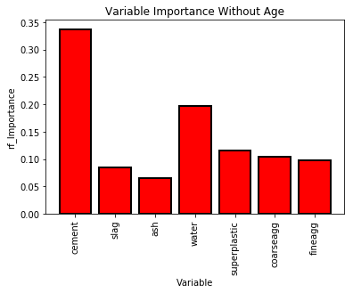

```python
## WITHOUT AGE FEATURE
# List of x locations for plotting
x_values_wo_age = list(range(len(rf_imp_wo_age)))

plt.bar(x_values_wo_age, rf_imp_wo_age, orientation='vertical', color = 'r', edgecolor = 'k', linewidth=2)

plt.xticks(x_values_wo_age, feature_list_wo_age, rotation='vertical')

plt.ylabel('rf_Importance')
plt.xlabel('Variable')
plt.title('Variable Importance Without Age')
```

```python
#4. Deliverable -4 (Tuning the model)
#a. Algorithms that you think will be suitable for this project
#b. Techniques employed to squeeze that extra performance out of the model without making it overfit or underfit
#c. Model performance range at 95% confidence level
```

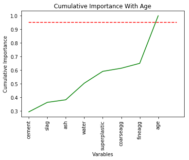

```python
# List of features sorted from most to least importance
sorted_importance = [importance[1] for importance in feature_importance]
sorted_feature = [importance[0] for importance in feature_importance]

cum_importance = np.cumsum(sorted_importance)

plt.plot(x_values, cum_importance, '-g')

plt.hlines(y=0.95, xmin=0, xmax=len(sorted_importance), color='r', linestyle='dashed')

plt.xticks(x_values, sorted_feature, rotation='vertical')

plt.xlabel('Varables')
plt.ylabel('Cumulative Importance')
plt.title('Cumulative Importance With Age')
```

```python
print ("Number of feartures of 95% Importance : ", np.where(cum_importance > 0.95)[0][0] + 1)
```

```
Number of feartures of 95% Importance :  8
```

Out of 8 features in total , we have used 8 features and in this we can see almost all the 8 features are important in predicting the model

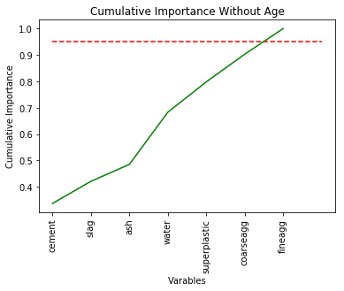

```python
## Without AGE feature
# List of features sorted from most to least importance
sorted_imp_wo_age = [importance[1] for importance in feature_imp_wo_age]
sorted_feature_wo_age = [importance[0] for importance in feature_imp_wo_age]

cum_imp_wo_age = np.cumsum(sorted_imp_wo_age)

plt.plot(x_values_wo_age, cum_imp_wo_age, '-g')

plt.hlines(y=0.95, xmin=0, xmax=len(sorted_imp_wo_age), color='r', linestyle='dashed')

plt.xticks(x_values_wo_age, sorted_feature_wo_age, rotation='vertical')

plt.xlabel('Varables')
plt.ylabel('Cumulative Importance')
plt.title('Cumulative Importance Without Age')
```

```python
print ("Number of feartures of 95% Importance, Without Age feature: ", np.where(cum_imp_wo_age > 0.95)[0][0] + 1)
```

```
Number of feartures of 95% Importance, Without Age feature:  7
```

We are checking 95% Importance with 7 features without Age feature, and almost all 7 features are important

### Trying PCA to improve performance

```python
conDF.columns
```

```
Index(['cement', 'slag', 'ash', 'water', 'superplastic', 'coarseagg',
       'fineagg', 'age', 'strength'],
      dtype='object')
```

```python
X_features = conDF.drop('strength' , axis = 1)

X_features.columns
```

```
Index(['cement', 'slag', 'ash', 'water', 'superplastic', 'coarseagg',
       'fineagg', 'age'],
      dtype='object')
```

```python
## Using PCA
cov_matrix = np.cov(X_features, rowvar=False)

np.linalg.eig(cov_matrix)

eigenvalues, eigenvectors, = np.linalg.eig(cov_matrix)

eig_pairs = [(eigenvalues[index], eigenvectors[:,index]) for index in range(len(eigenvalues))]

# Sort the (eigenvalue, eigenvector) pairs from lowest to highest with respect to eigenvalue
eig_pairs.sort()
eig_pairs.reverse()    # reverses the sorted pairs from increasing value of eigenvalue to lowest

# Extract the descending ordered eigenvalues and eigenvectors
eigvalues_sort = [eig_pairs[index][0] for index in range(len(eigenvalues))]
eigvectors_sort = [eig_pairs[index][1] for index in range(len(eigenvalues))]
```

```python
tot = sum(eigenvalues)

var_explained = [(i / tot) for i in sorted(eigenvalues, reverse=True)]  # an array of variance explained by each

cum_var_exp = np.cumsum(var_explained)  # an array of cumulative variance.

cum_var_exp
```

```
array([0.32576816, 0.57464249, 0.75944009, 0.86709951, 0.96804897,
       0.99789434, 0.9997123 , 1.        ])
```

Based on the above, we can see the first 5 features itself is delivering the 96% of contribution.

```python
conDF.columns
```

```
Index(['cement', 'slag', 'ash', 'water', 'superplastic', 'coarseagg',
       'fineagg', 'age', 'strength'],
      dtype='object')
```

```python
y_feature = np.array(conDF.pop('strength'))
```

```python
print ("y_feature Shape : ", y_feature.shape)
```

```
y_feature Shape :  (1030,)
```

```python
# Transform the data into PC dimensions

y_feature = y_feature.reshape(len(y_feature), 1)

eigen_space = np.array(eigvectors_sort[0:8]).transpose()

proj_data_3D = np.dot(X_features, eigen_space)

names = ['cement','slag','ash','water','superplastic','coarseagg','fineagg','age','strength']

pca_array = np.concatenate((proj_data_3D, y_feature), axis=1)
```

```python
proj_data_3D.shape
```

```
(1030, 8)
```

```python
pca_df = pd.DataFrame(pca_array ,columns=names )
pca_df.head()
```

|  | cement | slag | ash | water | superplastic | coarseagg | fineagg | age | strength |
| --- | --- | --- | --- | --- | --- | --- | --- | --- | --- |
| 0 | 89.928489 | -415.464330 | 256.530086 | -854.078669 | 27.873579 | 503.363590 | 606.972842 | -115.020692 | 29.89 |
| 1 | 62.662586 | -641.605263 | 321.032168 | -815.522820 | -0.229245 | 559.941524 | 601.717879 | -117.775821 | 23.51 |
| 2 | -17.703821 | -655.514257 | 179.124241 | -795.634912 | 31.440888 | 522.867567 | 617.825855 | -117.021221 | 29.22 |
| 3 | -65.729773 | -440.244315 | 263.055511 | -776.558650 | 14.470940 | 454.369700 | 602.649396 | -117.556266 | 45.85 |
| 4 | 60.064388 | -435.737653 | 345.031001 | -860.242379 | 15.015738 | 507.550878 | 593.980654 | -122.813640 | 18.29 |

```python
X = pca_array[:,0:1] # select only the PCAs
y = pca_array[:,1]   # select only the mpg column
X_train, X_test, y_train, y_test = train_test_split(X, y, test_size=0.30, random_state=7)
```

```python
rf_pca = RandomForestRegressor()
```

```python
rf_pca.fit(X_train, y_train)
y_predict = rf_pca.predict(X_test)
score = rf_pca.score(X_test, y_test)
mse, mae, rmse, r_sqrd = regression_scores(y_predict)
result('Random Forest PCA', score, mse, mae, rmse, r_sqrd)
result_df
```

|  | Method | Score | MSE | MAE | RMSE | R Squared |
| --- | --- | --- | --- | --- | --- | --- |
| 0 | Linear Regression | 0.622087 | 97.721037 | 7.812406 | 9.885395 | 0.622087 |
| 0 | Support Vector Regressor | 0.655883 | 88.982024 | 7.519929 | 9.433028 | 0.655883 |
| 0 | Decision Tree Regressor | 0.739815 | 67.278863 | 5.684126 | 8.202369 | 0.739815 |
| 0 | Random Forest Regressor | 0.828811 | 44.266133 | 5.089427 | 6.653280 | 0.828811 |
| 0 | Gradient Boosting Regressor | 0.833019 | 43.178135 | 5.144317 | 6.571007 | 0.833019 |
| 0 | Ada Boost Regressor | 0.722753 | 71.690841 | 6.978157 | 8.467044 | 0.722753 |
| 0 | Decision Tree Featurization | 0.629053 | 95.919878 | 7.639499 | 9.793869 | 0.629053 |
| 0 | Decision Tree Without Age | 0.311823 | 177.949305 | 10.584243 | 13.339764 | 0.311823 |
| 0 | Random Forest Featurization | 0.853910 | 37.775974 | 4.892567 | 6.146216 | 0.853910 |
| 0 | Random Forest Without Age | 0.498385 | 129.708161 | 9.250413 | 11.388949 | 0.498385 |
| 0 | Random Forest PCA | -0.168604 | 12072.749074 | 73.474823 | 109.876062 | -0.168604 |

### Trying out Ridge and Lasso

```python
from sklearn.linear_model import Ridge
from sklearn.linear_model import Lasso
```

```python
conDF = pd.read_csv('concrete.csv')
X = conDF.drop('strength',axis=1)
y = conDF[['strength']]
```

```python
from sklearn import preprocessing
```

```python
X_scaled = preprocessing.scale(X)
X_scaled = pd.DataFrame(X_scaled, columns=X.columns)  # ideally the training and test should be

y_scaled = preprocessing.scale(y)
y_scaled = pd.DataFrame(y_scaled, columns=y.columns)  # ideally the training and test should be
```

```python
X_train, X_test, y_train, y_test = train_test_split(X_scaled, y_scaled, test_size=0.30, random_state=7)
```

```python
ridge = Ridge(alpha=.3)
ridge.fit(X_train,y_train)
print ("Ridge model:", (ridge.coef_))
```

```
Ridge model: [[ 0.70056054  0.4927834   0.27389409 -0.23085271  0.11602728  0.05291175
   0.03162811  0.42341676]]
```

```python
lasso = Lasso(alpha=0.1)
lasso.fit(X_train,y_train)
print ("Lasso model:", (lasso.coef_))
```

```
Lasso model: [ 4.08491813e-01  1.76469060e-01  0.00000000e+00 -1.26536196e-01
  1.94404465e-01 -0.00000000e+00 -5.53354855e-05  2.68734243e-01]
```

```python
print(ridge.score(X_train, y_train))
print(ridge.score(X_test, y_test))
```

```
0.6108591368123688
0.6226929914085548
```

```python
print(lasso.score(X_train, y_train))
print(lasso.score(X_test, y_test))
```

```
0.5303270217272872
0.5430146713660124
```

```python
from sklearn.preprocessing import PolynomialFeatures
```

```python
poly = PolynomialFeatures(degree = 2, interaction_only=True)
```

```python
X_poly = poly.fit_transform(X_scaled)
X_train, X_test, y_train, y_test = train_test_split(X_poly, y, test_size=0.30, random_state=7)
X_train.shape
```

```
(721, 37)
```

```python
regression_model = LinearRegression()
regression_model.fit(X_train, y_train)
print(regression_model.coef_[0])
```

```
[-3.84050924e-16  1.28445288e+01  9.18506693e+00  5.47276435e+00
 -2.59527721e+00  3.47493206e+00 -2.32739482e-01  7.00619465e-01
  1.43919486e+01  1.65100965e+00  2.13677066e+00 -4.51761144e+00
 -3.91604950e+00  5.27715724e-01  1.31972259e+00  4.50451977e+00
  2.63055462e+00 -2.77270653e+00 -2.70813684e+00 -6.14157142e-01
  2.51130904e+00  5.09843552e+00 -3.23858207e+00 -4.16907023e+00
  5.17135016e-01  2.98219874e+00  7.84988443e+00 -8.72599335e-02
 -1.92831787e+00 -4.95309540e-01 -4.47470961e-01  5.87002466e-02
 -1.46371202e+00  1.93065237e+00  1.17901311e+00  9.59057399e-03
  3.14122419e+00]
```

```python
ridge = Ridge(alpha=.3)
ridge.fit(X_train,y_train)
print ("Ridge model:", (ridge.coef_))
```

```
Ridge model: [[ 0.         12.70602628  9.0445788   5.34645592 -2.68385943  3.4867694
  -0.29484247  0.58852817 14.36212246  1.6273465   2.11465463 -4.45625794
  -3.79296904  0.54290676  1.3180613   4.3334295   2.58490872 -2.72736203
  -2.59721575 -0.61454206  2.50776758  4.96160396 -3.18077112 -4.07277033
   0.51294442  2.97669338  7.67148254 -0.02378554 -1.90112617 -0.48536713
  -0.53773834  0.12360388 -1.37869457  1.97130538  1.18933811 -0.01585489
   3.01264106]]
```

```python
print(ridge.score(X_train, y_train))
print(ridge.score(X_test, y_test))
```

```
0.759644845079481
0.734378003828476
```

```python
lasso = Lasso(alpha=0.01)
lasso.fit(X_train,y_train)
print ("Lasso model:", (lasso.coef_))
```

```
Lasso model: [ 0.00000000e+00  1.25052096e+01  8.82589077e+00  5.13646524e+00
 -2.75741450e+00  3.54375658e+00 -3.04885176e-01  4.55756283e-01
  1.43022928e+01  1.52697681e+00  1.94091155e+00 -4.13473886e+00
 -3.15336151e+00  5.83852940e-01  1.29164317e+00  3.94531992e+00
  2.33308248e+00 -2.36301430e+00 -1.91585688e+00 -5.32580858e-01
  2.51366742e+00  4.64452230e+00 -2.92205780e+00 -3.52292472e+00
  4.26838175e-01  2.85047042e+00  7.30206071e+00  2.57426468e-01
 -1.79821587e+00 -3.53250147e-01 -6.37105125e-01  5.02303704e-01
 -8.57035409e-01  2.12639335e+00  1.23046570e+00 -2.64418649e-03
  2.75032077e+00]
```

```python
print(lasso.score(X_train, y_train))
print(lasso.score(X_test, y_test))
```

```
0.7594201112329407
0.7359972594843058
```

Using Ridge and Lasso, we still try this with Linear Regression model to check the performance improvement. So, overall we find that the Random Forest performs good among all.